# Part_1_Computer_Vision (1)

```python
#Import Drive from Google Colab
from google.colab import drive
drive.mount('/content/drive')
```

```python
# Setting the current working directory
import os; os.chdir('/content/drive/MyDrive/Colab Notebooks/Plant seedling classification data')
```

**1. Import the data. Analyse the dimensions of the data. Visualise the data.**

```python
#Import Library
import os
import numpy as np
import pandas as pd
import cv2
import matplotlib.pyplot as plt
%matplotlib inline

import warnings
warnings.filterwarnings('ignore')

from sklearn.model_selection import train_test_split
import itertools
from sklearn.metrics import accuracy_score, confusion_matrix
from keras.preprocessing import image
from keras.preprocessing.image import ImageDataGenerator
from keras.callbacks import ReduceLROnPlateau
from keras.models import Sequential, Model
from keras.layers import Dense, Activation, Flatten, Dropout, concatenate, Input, Conv2D, MaxPooling2D
from keras.optimizers import Adam, Adadelta
from keras.layers.advanced_activations import LeakyReLU
from keras.utils.np_utils import to_categorical
```

```python
train_dir = 'train'
test_dir = 'test'
sample_submission = pd.read_csv('sample_submission.csv')
```

```python
SPECIES = ['Black-grass', 'Charlock', 'Cleavers', 'Common Chickweed', 'Common wheat', 'Fat Hen',
              'Loose Silky-bent', 'Maize', 'Scentless Mayweed', 'Shepherds Purse',
              'Small-flowered Cranesbill', 'Sugar beet']

for species in SPECIES:
    print('{} {} images'.format(species, len(os.listdir(os.path.join(train_dir, species)))))
```

```
Black-grass 187 images
Charlock 343 images
Cleavers 285 images
Common Chickweed 611 images
Common wheat 208 images
Fat Hen 456 images
Loose Silky-bent 609 images
Maize 178 images
Scentless Mayweed 512 images
Shepherds Purse 220 images
Small-flowered Cranesbill 491 images
Sugar beet 308 images
```

```python
train = []

for species_num, species in enumerate(SPECIES):
    for file in os.listdir(os.path.join(train_dir, species)):
        train.append(['train/{}/{}'.format(species, file), species_num, species])

train = pd.DataFrame(train, columns=['file', 'species_num', 'species'])

print('Training Data: ',train.shape)
```

```
Training Data:  (4408, 3)
```

```python
def create_mask_for_plant(image):
    image_hsv = cv2.cvtColor(image, cv2.COLOR_BGR2HSV)

    sensitivity = 35
    lower_hsv = np.array([60 - sensitivity, 100, 50])
    upper_hsv = np.array([60 + sensitivity, 255, 255])

    mask = cv2.inRange(image_hsv, lower_hsv, upper_hsv)
    kernel = cv2.getStructuringElement(cv2.MORPH_ELLIPSE, (11,11))
    mask = cv2.morphologyEx(mask, cv2.MORPH_CLOSE, kernel)

    return mask

def segment_plant(image):
    mask = create_mask_for_plant(image)
    output = cv2.bitwise_and(image, image, mask = mask)
    return output

def sharpen_image(image):
    image_blurred = cv2.GaussianBlur(image, (0, 0), 3)
    image_sharp = cv2.addWeighted(image, 1.5, image_blurred, -0.5, 0)
    return image_sharp
```

```python
%%time

x_train = []

for i in range(len(train)):
    img = cv2.imread(train['file'][i])
    img = cv2.resize(img,dsize=(256,256))
    img_stack = segment_plant(img)
    img_stack = sharpen_image(img_stack)
    img_stack = cv2.cvtColor( img_stack, cv2.COLOR_RGB2GRAY )
    img_stack = np.reshape(img_stack,(256,256,1))
    x_train.append(np.concatenate((np.array(img),np.array(img_stack)),axis=2))

x_train = np.array(x_train)
```

```
CPU times: user 49.7 s, sys: 3.2 s, total: 52.9 s
Wall time: 55.8 s
```

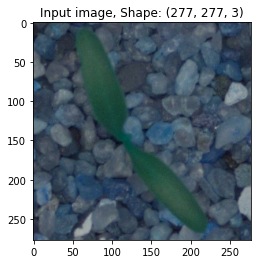

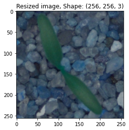

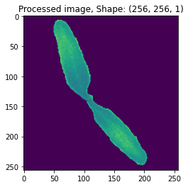

```python
# Sample Input image
Input_image = cv2.imread(train['file'][len(train)-1])

plt.imshow(Input_image)
plt.title('Input image, Shape: '+str(Input_image.shape))
plt.show()

# Resized image
plt.imshow(img)
plt.title('Resized image, Shape: '+str(img.shape))
plt.show()

# Processed image to Stack
plt.imshow(np.reshape(img_stack,(256,256)))
plt.title('Processed image, Shape: '+str(img_stack.shape))
plt.show()
```

```python
#One-hot Encoding
labels = train['species_num']
labels = to_categorical(labels, num_classes = len(SPECIES))
```

**2. Train tune and test AIML image classifier model using:**

```python
x_train, x_val, y_train, y_val = train_test_split(x_train, labels, test_size = 0.1, random_state=10)
```

```python
input_shape = x_train[1].shape
print('Input Shape is :', input_shape)
```

```
Input Shape is : (256, 256, 4)
```

**2.C Use CNN for training**

```python
#CNN Architecture
def fire_incept(x, fire=16, intercept=64):
    x = Conv2D(fire, (5,5), strides=(2,2))(x)
    x = LeakyReLU(alpha=0.15)(x)

    left = Conv2D(intercept, (3,3), padding='same')(x)
    left = LeakyReLU(alpha=0.15)(left)

    right = Conv2D(intercept, (5,5), padding='same')(x)
    right = LeakyReLU(alpha=0.15)(right)

    x = concatenate([left, right], axis=3)
    return x

def fire_squeeze(x, fire=16, intercept=64):
    x = Conv2D(fire, (1,1))(x)
    x = LeakyReLU(alpha=0.15)(x)

    left = Conv2D(intercept, (1,1))(x)
    left = LeakyReLU(alpha=0.15)(left)

    right = Conv2D(intercept, (3,3), padding='same')(x)
    right = LeakyReLU(alpha=0.15)(right)

    x = concatenate([left, right], axis=3)
    return x

image_input=Input(shape=input_shape)

x = fire_incept((image_input), fire=16, intercept=16)

x = fire_incept(x, fire=32, intercept=32)
x = fire_squeeze(x, fire=32, intercept=32)

x = fire_incept(x, fire=64, intercept=64)
x = fire_squeeze(x, fire=64, intercept=64)

x = fire_incept(x, fire=64, intercept=64)
x = fire_squeeze(x, fire=64, intercept=64)

x = Conv2D(64, (3,3))(x)
x = LeakyReLU(alpha=0.1)(x)

x = Flatten()(x)

x = Dense(512)(x)
x = LeakyReLU(alpha=0.1)(x)
x = Dropout(0.1)(x)

out = Dense(len(SPECIES), activation='softmax')(x)

model_new = Model(image_input, out)
model_new.summary()
```

```
Model: "model_2"
__________________________________________________________________________________________________
Layer (type)                    Output Shape         Param #     Connected to
==================================================================================================
input_3 (InputLayer)            [(None, 256, 256, 4) 0
__________________________________________________________________________________________________
conv2d_44 (Conv2D)              (None, 126, 126, 16) 1616        input_3[0][0]
__________________________________________________________________________________________________
leaky_re_lu_46 (LeakyReLU)      (None, 126, 126, 16) 0           conv2d_44[0][0]
__________________________________________________________________________________________________
conv2d_45 (Conv2D)              (None, 126, 126, 16) 2320        leaky_re_lu_46[0][0]
__________________________________________________________________________________________________
conv2d_46 (Conv2D)              (None, 126, 126, 16) 6416        leaky_re_lu_46[0][0]
__________________________________________________________________________________________________
leaky_re_lu_47 (LeakyReLU)      (None, 126, 126, 16) 0           conv2d_45[0][0]
__________________________________________________________________________________________________
leaky_re_lu_48 (LeakyReLU)      (None, 126, 126, 16) 0           conv2d_46[0][0]
__________________________________________________________________________________________________
concatenate_14 (Concatenate)    (None, 126, 126, 32) 0           leaky_re_lu_47[0][0]
                                                                 leaky_re_lu_48[0][0]
__________________________________________________________________________________________________
conv2d_47 (Conv2D)              (None, 61, 61, 32)   25632       concatenate_14[0][0]
__________________________________________________________________________________________________
leaky_re_lu_49 (LeakyReLU)      (None, 61, 61, 32)   0           conv2d_47[0][0]
__________________________________________________________________________________________________
conv2d_48 (Conv2D)              (None, 61, 61, 32)   9248        leaky_re_lu_49[0][0]
__________________________________________________________________________________________________
conv2d_49 (Conv2D)              (None, 61, 61, 32)   25632       leaky_re_lu_49[0][0]
__________________________________________________________________________________________________
leaky_re_lu_50 (LeakyReLU)      (None, 61, 61, 32)   0           conv2d_48[0][0]
__________________________________________________________________________________________________
leaky_re_lu_51 (LeakyReLU)      (None, 61, 61, 32)   0           conv2d_49[0][0]
__________________________________________________________________________________________________
concatenate_15 (Concatenate)    (None, 61, 61, 64)   0           leaky_re_lu_50[0][0]
                                                                 leaky_re_lu_51[0][0]
__________________________________________________________________________________________________
conv2d_50 (Conv2D)              (None, 61, 61, 32)   2080        concatenate_15[0][0]
__________________________________________________________________________________________________
leaky_re_lu_52 (LeakyReLU)      (None, 61, 61, 32)   0           conv2d_50[0][0]
__________________________________________________________________________________________________
```

[output cut: 74 more lines]

```
__________________________________________________________________________________________________
flatten_2 (Flatten)             (None, 7744)         0           leaky_re_lu_67[0][0]
__________________________________________________________________________________________________
dense_4 (Dense)                 (None, 512)          3965440     flatten_2[0][0]
__________________________________________________________________________________________________
leaky_re_lu_68 (LeakyReLU)      (None, 512)          0           dense_4[0][0]
__________________________________________________________________________________________________
dropout_2 (Dropout)             (None, 512)          0           leaky_re_lu_68[0][0]
__________________________________________________________________________________________________
dense_5 (Dense)                 (None, 12)           6156        dropout_2[0][0]
==================================================================================================
Total params: 4,813,436
Trainable params: 4,813,436
Non-trainable params: 0
__________________________________________________________________________________________________
```

```python
#Complile the Model
model_new.compile(optimizer = Adam(lr=.00025) , loss = 'categorical_crossentropy', metrics=['accuracy'])
```

```python
#Set a learning rate annealer
learning_rate_reduction = ReduceLROnPlateau(monitor='val_acc', patience=3, verbose=1,
                                            factor=0.5, min_lr=0.00001)
```

```python
#Data Augumentation
datagen = ImageDataGenerator(rotation_range=40, zoom_range = 0.2, width_shift_range=0.2, height_shift_range=0.2,
                             horizontal_flip=True, vertical_flip=True)
datagen.fit(x_train)
```

```python
batch_size = 32
epochs = 3
```

```python
#Fit the Model
history = model_new.fit_generator(datagen.flow(x_train,y_train, batch_size=batch_size), epochs = epochs,
                                  validation_data = (x_val,y_val), verbose = 1,
                                  steps_per_epoch=x_train.shape[0] // batch_size,
                                  callbacks=[learning_rate_reduction])
```

```
WARNING:tensorflow:Learning rate reduction is conditioned on metric `val_acc` which is not available. Available metrics are: loss,accuracy,val_loss,val_accuracy,lr
WARNING:tensorflow:Learning rate reduction is conditioned on metric `val_acc` which is not available. Available metrics are: loss,accuracy,val_loss,val_accuracy,lr
WARNING:tensorflow:Learning rate reduction is conditioned on metric `val_acc` which is not available. Available metrics are: loss,accuracy,val_loss,val_accuracy,lr
```

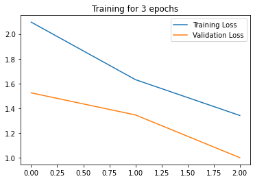

```python
plt.plot(history.history['loss'])
plt.plot(history.history['val_loss'])
plt.title('Training for ' +str(epochs)+ ' epochs')
plt.legend(['Training Loss', 'Validation Loss'], loc='upper right')
plt.show()
```

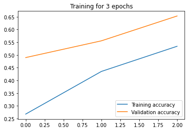

```python
plt.plot(history.history['accuracy'])
plt.plot(history.history['val_accuracy'])
plt.title('Training for ' +str(epochs)+ ' epochs')
plt.legend(['Training accuracy', 'Validation accuracy'], loc='lower right')
plt.show()
```

```python
#Save the Model weights
model_new.save_weights('saved_models/model_weights_2.h5f5', overwrite=True)
```

```python
#Predictions

%%time

test = []
for file in os.listdir(os.path.join(test_dir)):
    test.append(['test/{}'.format(file)])

test = pd.DataFrame(test, columns=['file'])
print(test.head(5))


x_test = []

for i in range(len(test)):
    img = cv2.imread(test['file'][i])
    img = cv2.resize(img,dsize=(256,256))
    img_stack = segment_plant(img)
    img_stack = sharpen_image(img_stack)
    img_stack = cv2.cvtColor( img_stack, cv2.COLOR_RGB2GRAY )
    img_stack = np.reshape(img_stack,(256,256,1))
    x_test.append(np.concatenate((np.array(img),np.array(img_stack)),axis=2))

x_test = np.array(x_test)
```

```
                 file
0  test/f9b6bfb00.png
1  test/fea3da57c.png
2  test/f1f7c833f.png
3  test/fe29629fb.png
4  test/f48916a8c.png
CPU times: user 7.7 s, sys: 562 ms, total: 8.26 s
Wall time: 8.63 s
```

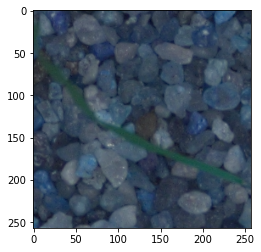

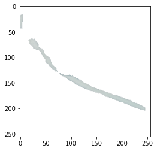

```python
#Sample test images
randm = np.random.randint(0,len(test))

img = cv2.imread(test['file'][randm])
plt.imshow(img)
plt.show()

img_processed = x_test[randm]
plt.imshow(img_processed)
plt.show()
```

```python
#Prediction on test set
Pred_labels = np.argmax(model_new.predict(x_test),axis = 1)
```

```python
Pred_labels = pd.DataFrame(Pred_labels,index =None,columns=['species_num'])

test_id = []
for file in os.listdir(test_dir):
    test_id.append(['{}'.format(file)])

test_id = pd.DataFrame(test_id, columns=['file'])

test_df = pd.DataFrame()
test_df['species_num'] = Pred_labels['species_num']
test_df['file'] = test_id['file']
test_df['species'] = [SPECIES[i] for i in Pred_labels['species_num']]

submission = pd.merge(left=sample_submission, right=test_df[['file', 'species']], on="file", how="right")
submission.drop(['species_x'], axis = 1, inplace = True)
submission.columns = ['file','species']

submission.to_csv('submission.csv', index=False)
print(submission.head())
```

```
            file          species
0  f9b6bfb00.png         Cleavers
1  fea3da57c.png       Sugar beet
2  f1f7c833f.png  Shepherds Purse
3  fe29629fb.png          Fat Hen
4  f48916a8c.png          Fat Hen
```

**2.A Use supervised learning algorithms for training**

```python
#Extracting Features from last Laye
model_feat = Model(inputs=model_new.input,outputs=model_new.get_layer('dense_5').output)

feat_train = model_feat.predict(x_train)
print(feat_train.shape)

feat_val = model_feat.predict(x_val)
print(feat_val.shape)

feat_test = model_feat.predict(x_test)
print(feat_test.shape)
```

```
(3967, 12)
(441, 12)
(795, 12)
```

```python
#Logistic Regression
from sklearn.linear_model import LogisticRegression

logreg = LogisticRegression(multi_class='multinomial', solver='lbfgs')
logreg.fit(feat_train,np.argmax(y_train,axis=1))
```

```
LogisticRegression(C=1.0, class_weight=None, dual=False, fit_intercept=True,
                   intercept_scaling=1, l1_ratio=None, max_iter=100,
                   multi_class='multinomial', n_jobs=None, penalty='l2',
                   random_state=None, solver='lbfgs', tol=0.0001, verbose=0,
                   warm_start=False)
```

```python
#Print accuracy score of train,valid data
logreg.score(feat_train,np.argmax(y_train,axis=1))
```

[output not shown]

```python
logreg.score(feat_val,np.argmax(y_val,axis=1))
```

```
0.14512471655328799
```

```python
 logreg_test= logreg.predict(feat_test)
```

```python
logreg_test = pd.DataFrame(logreg_test,index =None,columns=['species_num'])

test_df = pd.DataFrame()
test_df['species_num'] = logreg_test['species_num']
test_df['file'] = test_id['file']
test_df['species'] = [SPECIES[i] for i in logreg_test['species_num']]

logregression = pd.merge(left=sample_submission, right=test_df[['file', 'species']], on="file", how="right")
logregression.drop(['species_x'], axis = 1, inplace = True)
logregression.columns = ['file','species']
print(logregression.head())

logregression.to_csv('logregression.csv', index=False)
```

```
            file           species
0  f9b6bfb00.png  Loose Silky-bent
1  fea3da57c.png  Loose Silky-bent
2  f1f7c833f.png  Common Chickweed
3  fe29629fb.png  Loose Silky-bent
4  f48916a8c.png  Loose Silky-bent
```

**3& 4.3. Compare the results from the above step along with your detailed observations.4. Pickle the best performing model**.

Out of the other Models, CNN model has the highest accuracy of 65.31% while taking less number of EPOCH's = 3 which outperforms other models as well in image classification dataset. So, CNN is the best perfroming model

1. Import the the image in the “ Prediction” folder to predict the class. Display the image. Use the best trained image classifier model to predict the class.

```python
import numpy as np
import pandas as pd
from glob import glob
import cv2
import matplotlib.pyplot as plt
from PIL import ImageFile
ImageFile.LOAD_TRUNCATED_IMAGES = True
from tqdm import tqdm
import time
%matplotlib inline

from sklearn.datasets import load_files
from sklearn.model_selection import train_test_split
from sklearn.metrics import confusion_matrix, classification_report
import seaborn as sns

from keras.utils import np_utils
from keras.preprocessing import image
from keras.models import Sequential, model_from_json
from keras.callbacks import ModelCheckpoint, ReduceLROnPlateau
from keras.preprocessing.image import ImageDataGenerator, array_to_img, img_to_array, load_img
from keras.layers import Conv2D, MaxPooling2D, GlobalAveragePooling2D, Dropout, Flatten, Dense ,Input
from keras.optimizers import Adam ,RMSprop
```

```python
def path_to_tensor(img_path):
    # loads RGB image as PIL.Image.Image type
    img = image.load_img(img_path, target_size=(256, 256))
    # convert PIL.Image.Image type to 3D tensor with shape (256, 256, 3)
    x = image.img_to_array(img)
    # convert 3D tensor to 4D tensor with shape (1, 256, 256, 3) and return 4D tensor
    return np.expand_dims(x, axis=0)

def paths_to_tensor(img_paths):
    list_of_tensors=[]
    list_of_tensors = [path_to_tensor(img_path) for img_path in tqdm(img_paths)]
    return np.vstack(list_of_tensors)
```

```python
def plant_seed_classification(image):

    image = path_to_tensor(image).astype('float32')/255

    json_file = open('saved_models/model_weights_2.h5f5.data-00000-of-00001', 'r')
    loaded_model_json = json_file.read()
    json_file.close()
    model = model_from_json(loaded_model_json)
    # load weights into new model
    model.load_weights("saved_models/model_weights_2.h5f5.data-00000-of-00001")
    print("Loaded model from disk")

    prediction = model.predict_classes(image)

    print('The predicted Class of the image is {}'.format(prediction))
    INV_CLASS = {
    0: 'Black-grass',
    1: 'Charlock',
    2: 'Cleavers',
    3: 'Common Chickweed',
    4: 'Common wheat',
    5: 'Fat Hen',
    6: 'Loose Silky-bent',
    7: 'Maize',
    8: 'Scentless Mayweed',
    9: 'Shepherds Purse',
    10: 'Small-flowered Cranesbill',
    11: 'Sugar beet'
     }
    print('The class of the plant is',[INV_CLASS[p] for p in prediction])
```

```python
plant_seed_classification('/content/drive/MyDrive/Colab Notebooks/Plant seedling classification data/Prediction/1b490196c.png')
```

[output not shown]

**Part 2** -Explain in depth why CNN out performs neural networks which in turn out perform supervised learning models when it comes to image classification. Use the markdown option in Jupiter for your answer

CNN convolves learned features with input data, and uses 2D convolutional layers, making this architecture well suited to processing 2D data, such as images. Since CNNs eliminate the need for manual feature extraction, one doesn’t need to select features required to classify the images. How CNN work is by extracting features directly from images and the key features are not pretrained; they are learned while the network trains on a collection of images, the post notes. It is the automated feature extraction that makes CNNs highly suited for and accurate for computer vision tasks such as object/image classification.